# Final_work_coad

# Setup

```r
library(biomaRt)
library("knitr")
library(rlist)
library(edgeR)
library(statmod)
library(org.Hs.eg.db)
library(RSQLite) #
library(IRanges)
library(ChIPpeakAnno)
```

```r
TASK <- "grosell"
HOME <- '~'
WD <-  file.path(HOME, TASK)
dir.create(WD, 'data')

opts_chunk$set(fig.width = 12,
               fig.height = 12,
               cache = TRUE,
               include = TRUE,
               cache.lazy = FALSE,
               warning = TRUE,
               message = TRUE)
```

# TFBS data retrieval

For transfac + fimo scans

### Fimo download:

```bash
mkdir -p utils

cd $_
# retrieving transfac+fimo
wget -q https://noble.gs.washington.edu/custom-tracks/fimo.hg19.transfac-0.1.bb

# getting the exec for linux 64 bits

rsync -aP rsync://hgdownload.soe.ucsc.edu/genome/admin/exe/linux.x86_64/bigBedToBed .

# making it runnable

chmod a+x bigBedToBed

# converting to bed

./bigBedToBed fimo.hg19.transfac-0.1.bb test.bed

# checking how a bedfile looks like

head test.bed

cut -f4 test.bed | sort | uniq -c | sed 's/^\s*//' > fimo_transfac.txt
sort test.bed | uniq -c | sed 's/^\s*//' > fimo_transfac_1.txt
mv fimo_transfac.txt ../data
mv fimo_transfac_1.txt ../data
```

```
## receiving incremental file list
## chr1 10000   10015   TRF1    585 -
## chr1 10006   10021   TRF1    585 -
## chr1 10012   10027   TRF1    585 -
## chr1 10018   10033   TRF1    585 -
## chr1 10024   10039   TRF1    585 -
## chr1 10030   10045   TRF1    585 -
## chr1 10036   10051   TRF1    585 -
## chr1 10042   10057   TRF1    585 -
## chr1 10048   10063   TRF1    585 -
## chr1 10054   10069   TRF1    585 -
```

### Adding the Fimo list into R

```r
fimo_transfac <- unique(read.table(file.path('data', 'fimo_transfac.txt'),
                                header = FALSE,
                                stringsAsFactors = FALSE))
colnames(fimo_transfac)<- c("Number", "tf")
```

```r
fimo_transfac_1 <- read.table(file.path('data', 'fimo_transfac_1.txt'), header = FALSE)
fimo_transfac_1<-fimo_transfac_1[,-1]
colnames(fimo_transfac_1)<-c("chromosome","start","end","id","nb","strand")
```

```r
cmd <- 'wget https://noble.gs.washington.edu/custom-tracks/fimo.hg19.jaspar_core-0.1.bb;
utils/bigBedToBed fimo.hg19.jaspar_core-0.1.bb jaspar_hg19.bed'
system(cmd)
file.rename('jaspar_hg19.bed', file.path('data', 'jaspar_hg19.bed'))
```

```
## [1] FALSE
```

```r
file.remove('fimo.hg19.jaspar_core-0.1.bb')
```

```
## [1] FALSE
```

```r
## @todo fix this these are extremely few!!!
jaspar_ids <- unique(read.table(file.path('data', 'jaspar_hg19.bed'),
                                header = FALSE,
                                stringsAsFactors = FALSE)$V4)
jaspar.prueba<-unique(read.table(file.path('data', 'jaspar_hg19.bed')))
```

# Mapping

### Symbols

We would like to transform TRANSFAC names to HUGO symbols (we’ll check differential expression of these using TCGA RSEM data) Transformation of Fimo list (TRANSFAC names) to match our TCGA RSEM data:

```r
con <- org.Hs.eg_dbconn()

stmt <- 'SELECT * FROM alias, gene_info WHERE alias._id == gene_info._id;'
# execute the query on the database
aliases <- dbGetQuery(con, stmt)

candidates <- aliases[aliases$alias_symbol %in% toupper(fimo_transfac$tf),]
candidates2 <- aliases[aliases$symbol %in% toupper(fimo_transfac$tf),]

valid_symbols <- unique(candidates$symbol, candidates2$symbol)
```

### Entrez IDs

Gene symbols to Entrez gene ids (TCGA RSEMs also provide these identifiers)

```r
mart <- useMart("ENSEMBL_MART_ENSEMBL", host="grch37.ensembl.org",
                path="/biomart/martservice", dataset="hsapiens_gene_ensembl")


entrez_tf <- getBM(attributes=c('hgnc_symbol',
                                'entrezgene'),
                   filters = 'external_gene_name',
                   values = valid_symbols,
                   mart = mart)
```

### For FIMO:

```r
fimo_transfac_1<-fimo_transfac_1[fimo_transfac_1$id %in% entrez_tf$hgnc_symbol,]
fimo_transfac_1<-fimo_transfac_1[unique(fimo_transfac_1$start),]
fimo_transfac_1<-fimo_transfac_1[complete.cases(fimo_transfac_1),]
```

```r
library(ChIPpeakAnno)
bed.ranges.fimo<-toGRanges(fimo_transfac_1, format= "BED", header= FALSE)
```

```
## duplicated or NA names found. Rename all the names by numbers.
```

```r
library(EnsDb.Hsapiens.v75)
annoData <- toGRanges(EnsDb.Hsapiens.v75, feature= "gene")
```

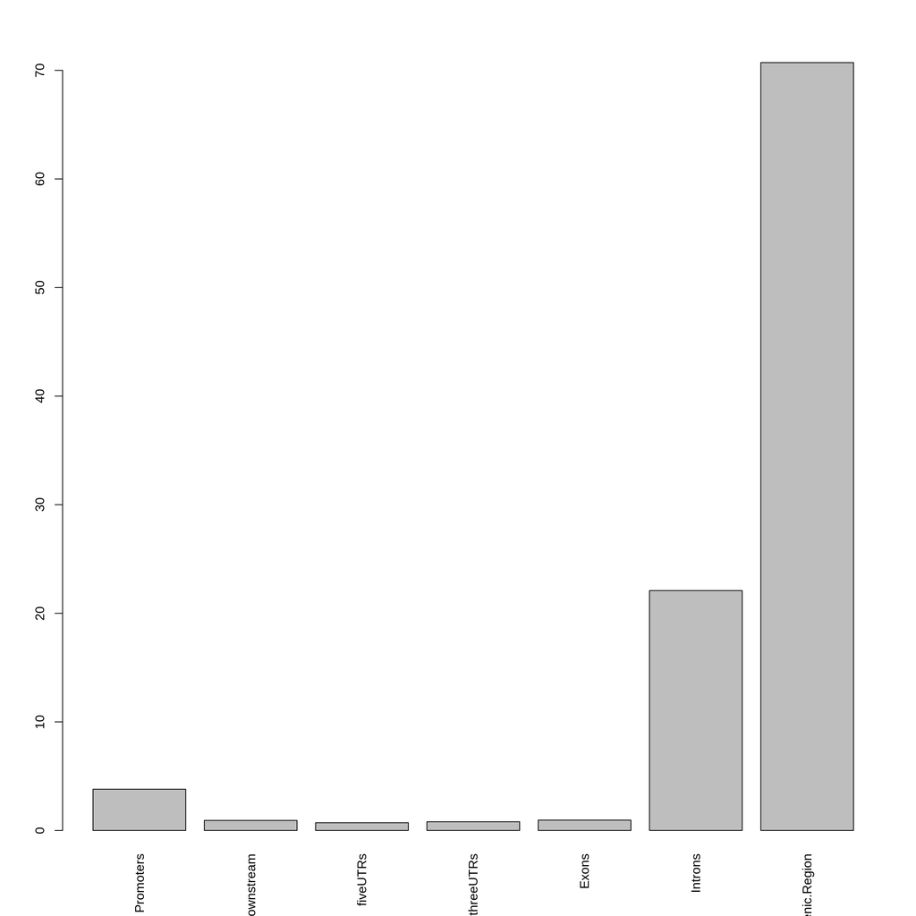

```r
library(TxDb.Hsapiens.UCSC.hg19.knownGene)
aCR<-assignChromosomeRegion(bed.ranges.fimo, nucleotideLevel=FALSE,
                           precedence=c("Promoters", "immediateDownstream",
                                         "fiveUTRs", "threeUTRs",
                                         "Exons", "Introns"),
                           TxDb=TxDb.Hsapiens.UCSC.hg19.knownGene)
barplot(aCR$percentage, las=3)
```

```r
overlaps.anno.fimo <- annotatePeakInBatch(bed.ranges.fimo,
                                     AnnotationData=annoData,
                                     output="nearestBiDirectionalPromoters",
                                     bindingRegion=c(-2000, 500))
```

```
## Annotate peaks by annoPeaks, see ?annoPeaks for details.
```

```
## maxgap will be ignored.
```

```r
library(org.Hs.eg.db)
overlaps.anno.fimo <- addGeneIDs(overlaps.anno.fimo,
                            "org.Hs.eg.db",
                            IDs2Add = "entrez_id")
```

### For JASPAR:

```r
colnames(jaspar.prueba)<-c("chromosome","start","end","id","nb","strand")
jaspar.prueba.1<-jaspar.prueba[jaspar.prueba$id %in% jaspar_ids,]
jaspar.prueba.1<-jaspar.prueba.1[unique(jaspar.prueba.1$start),]
jaspar.prueba.1<-jaspar.prueba.1[complete.cases(jaspar.prueba.1),]
```

```r
jaspar.ranges<-toGRanges(jaspar.prueba.1, format= "BED", header= FALSE)
```

```
## duplicated or NA names found. Rename all the names by numbers.
```

```r
annoData <- toGRanges(EnsDb.Hsapiens.v75, feature= "gene")
```

```r
overlaps.anno.jaspar <- annotatePeakInBatch(jaspar.ranges,
                                     AnnotationData=annoData,
                                     output="nearestBiDirectionalPromoters",
                                     bindingRegion=c(-2000, 500))
```

```
## Annotate peaks by annoPeaks, see ?annoPeaks for details.
```

```
## maxgap will be ignored.
```

```r
overlaps.anno.jaspar <- addGeneIDs(overlaps.anno.jaspar,
                            "org.Hs.eg.db",
                            IDs2Add = "entrez_id")
```

# RSEM download:

### COAD

```r
download.file('http://gdac.broadinstitute.org/runs/stddata__2016_01_28/data/COAD/20160128/gdac.broadinstitute.org_COAD.Merge_rnaseqv2__illuminahiseq_rnaseqv2__unc_edu__Level_3__RSEM_genes_normalized__data.Level_3.2016012800.0.0.tar.gz',  destfile = file.path(WD, 'coad_rsem.tar.gz'))

coad.fn <- grep('data.txt', untar(file.path(WD, 'coad_rsem.tar.gz'), list = TRUE), value = TRUE)
untar(file.path(WD, 'coad_rsem.tar.gz'), files = coad.fn)

header.coad <- read.table(file = coad.fn, sep = '\t', header = FALSE, nrow = 1,
                     stringsAsFactors = FALSE)

coad <- read.table(file = coad.fn, sep = '\t', header = TRUE, skip = 2)
colnames(coad) <- header.coad[1,]

rownames(coad) <- coad[,1]
coad <- coad[,-1]
rm(header.coad)
```

# Defining the mapping function:

Getting a dictionary of TF with their TCGA id, Entrez id and standard gene symbol for which we know the TRANSFAC/FIMO motif. TO DO WITH A GENERIC FUNCTION, SO WE CAN USE IN THE IN A LITTLE CHUNK FOR EACH TCGA DATA.

```r
mapping <- data.frame(tcga = rownames(coad),
                      entrez = sapply(strsplit(rownames(coad), '|', fixed = TRUE),
                                      function(x) return(x[2])),
                      symbol = sapply(strsplit(rownames(coad), '|', fixed = TRUE),
                                      function(x) return(x[1])))

tf <- merge(mapping, entrez_tf, by.x = 'entrez', by.y = 'entrezgene')


## so tf$tcga will contain the TCGA identifiers (rownames of COAD)
head(coad[tf$tcga,])
```

[output not shown]

[output cut: 602 more lines]

[output not shown]

# Analysis:

I have in mind we can try to compare between normal and tumor and then compare between participants, lets see the preliminary results what they show:

## Diff expression:

### Normal vs tumor, paired mode:

Getting sort of counts from RSEMs (this is not correct because we are just rounding RSEMs!) and generating a DGE object only for those samples that come from the same patient, because we will compare tumors against matched normals.

```r
coad.r <- round(coad)

coad.data <- data.frame(barcode = colnames(coad),
                      sample = strtrim(sapply(strsplit(colnames(coad), '-', fixed = TRUE),
                                              function(x) return(x[4])), 2),
                      participant = sapply(strsplit(colnames(coad), '-', fixed = TRUE),
                                              function(x) return(x[3]))
                      )
#Participants that have normal vs tumor tissue comparision:
head(coad.data)
```

```
##                        barcode sample participant
## 1 TCGA-3L-AA1B-01A-11R-A37K-07     01        AA1B
## 2 TCGA-4N-A93T-01A-11R-A37K-07     01        A93T
## 3 TCGA-4T-AA8H-01A-11R-A41B-07     01        AA8H
## 4 TCGA-5M-AAT4-01A-11R-A41B-07     01        AAT4
## 5 TCGA-5M-AAT5-01A-21R-A41B-07     01        AAT5
## 6 TCGA-5M-AAT6-01A-11R-A41B-07     01        AAT6
```

```r
dim(coad.data)
```

```
## [1] 328   3
```

```r
table(coad.data$sample)
```

```
##
##  01  02  06  11
## 285   1   1  41
```

```r
## only normals and primary tumors
coad.data.1 <- coad.data[coad.data$sample %in% c('01', '11'),]

## only matched normal and tumor from the same participant
selected <- coad.data.1$participant[duplicated(coad.data.1$participant)]
coad.data.2 <- coad.data.1[coad.data.1$participant %in% selected,]
coad.barcode <- coad[,coad.data.2$barcode]

coad_dge <- DGEList(coad.barcode, samples = coad.data.2)
```

Norm factors

```r
coad_dge <- calcNormFactors(coad_dge)
```

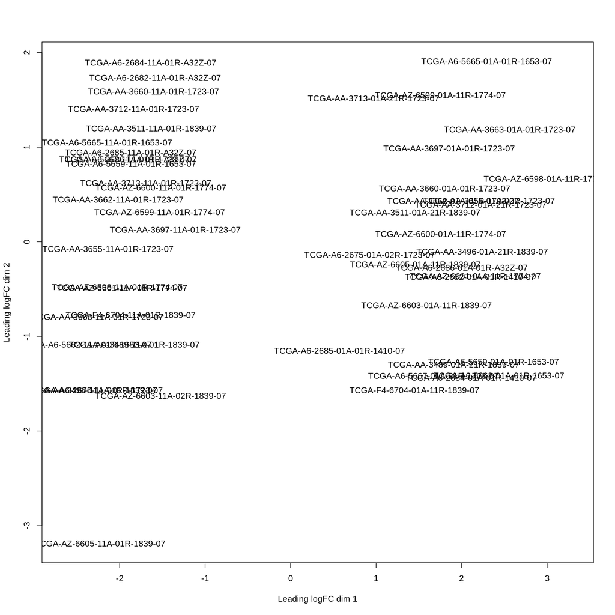

```r
plotMDS(coad_dge_norm)
```

Desing the matrix for the analysis:

```r
coad.data.2$sample <- as.factor(as.character(coad.data.2$sample))
coad.data.2$participant <- as.factor(as.character(coad.data.2$participant))
mmatrix <- model.matrix(~ 0 + sample + participant, data = coad.data.2)
rownames(mmatrix) <- coad.data.2$barcode
dim(mmatrix)
```

```
## [1] 52 27
```

```r
coad_dge <- estimateDisp(coad_dge, mmatrix,robust = FALSE)
```

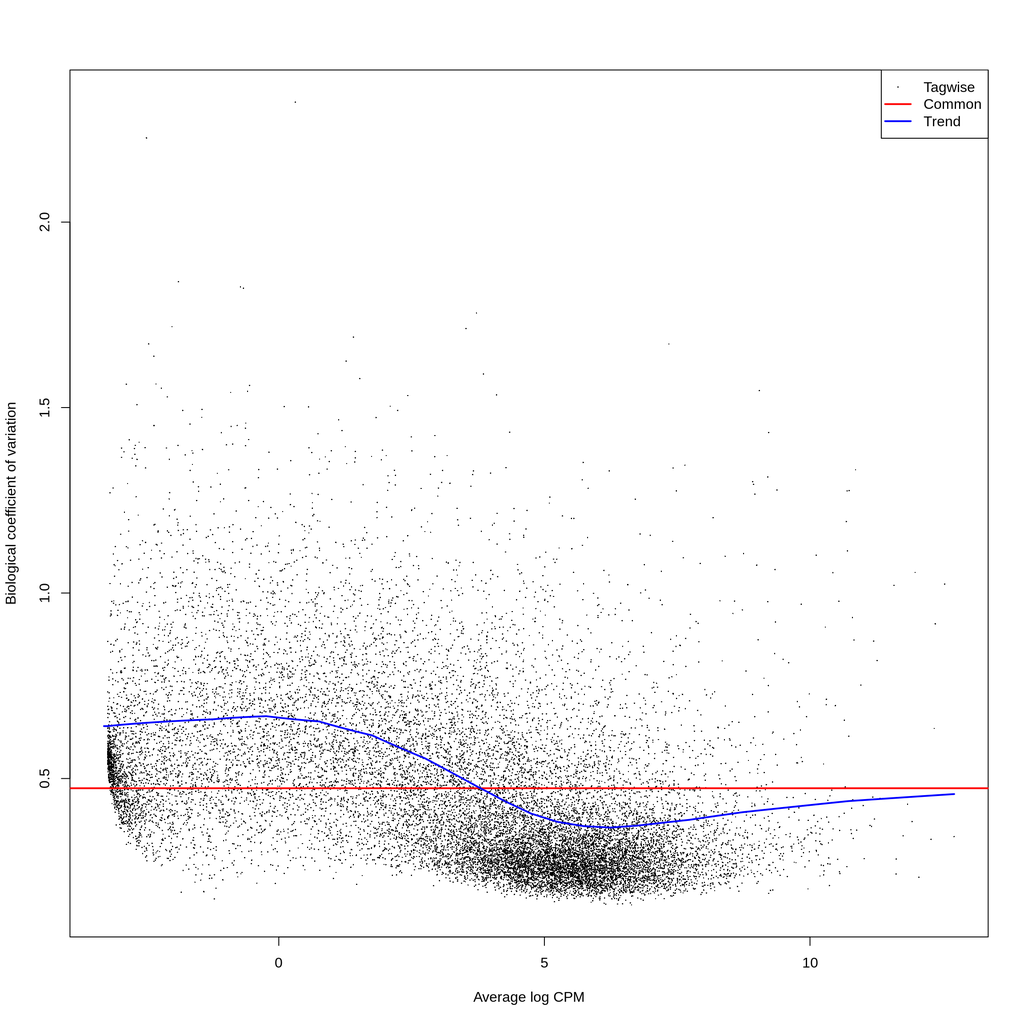

```r
plotBCV(coad_dge)
```

```r
coad_fit <-glmFit( coad_dge, mmatrix)
contrast<-c(1,-1,rep(0,25))
coad_fit.1 <- glmLRT(coad_fit, contrast = contrast)
topTags(coad_fit.1)
```

```
## Coefficient:  1*sample01 -1*sample11
##                            logFC   logCPM       LR        PValue
## LOC100190940|100190940 -8.791640 2.957769 695.2555 3.216866e-153
## TRIB3|57761            -3.663367 5.501643 508.4816 1.356965e-112
## KRT80|144501           -7.068597 4.624168 474.7864 2.912281e-105
## GRIN2D|2906            -5.419909 4.475104 362.4459  8.260305e-81
## FOXQ1|94234            -5.789248 4.673567 360.4352  2.263739e-80
## ESM1|11082             -5.939841 2.076020 359.2999  3.999696e-80
## KLK8|11202             -8.765420 1.218269 343.4137  1.151981e-76
## KIAA1257|57501         -3.900621 1.829629 337.2413  2.544883e-75
## OSBPL3|26031           -2.071476 4.987843 327.1115  4.091753e-73
## CLDN1|9076             -4.708776 5.795437 305.1281  2.515201e-68
##                                  FDR
## LOC100190940|100190940 6.604225e-149
## TRIB3|57761            1.392924e-108
## KRT80|144501           1.992971e-101
## GRIN2D|2906             4.239601e-77
## FOXQ1|94234             9.294912e-77
## ESM1|11082              1.368563e-76
## KLK8|11202              3.378595e-73
## KIAA1257|57501          6.530807e-72
## OSBPL3|26031            9.333744e-70
## CLDN1|9076              5.163707e-65
```

Differential expression:

```r
summary(decideTests(coad_fit.1))
```

```
##        1*sample01 -1*sample11
## Down                     5558
## NotSig                   9206
## Up                       5766
```

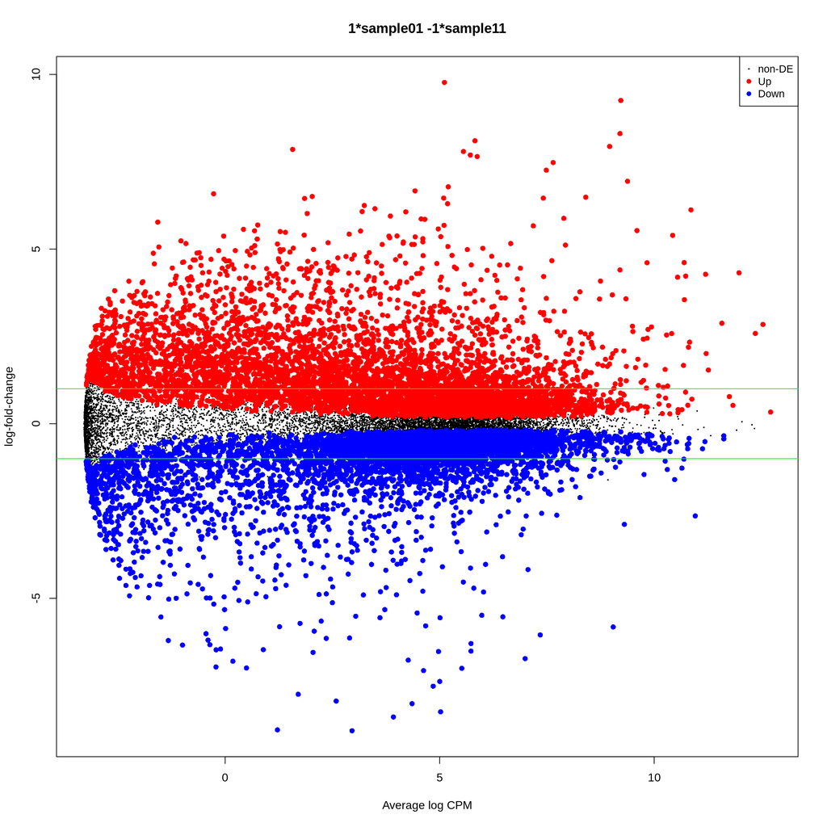

```r
plotMD(coad_fit.1)
abline(h=c(-1, 1), col="green")
```

### Normal vs Tumor, general:

```r
#this way we split the rownames between the hgnc symbol and their number:
coad.TF.list<-coad[sapply(strsplit(rownames(coad), '|', fixed = TRUE),
                                              function(x) return(x[2])) %in% entrez_tf$entrezgene,]
```

```r
coad_dge_norm_general<-DGEList(coad.TF.list)
coad_dge_norm_general<-calcNormFactors(coad_dge_norm_general)
coad_general<-estimateCommonDisp(coad_dge_norm_general)
```

```r
Normal.g<-factor(c("11"== strtrim(sapply(strsplit(colnames(coad_general), '-', fixed = TRUE),
                                              function(x) return(x[4])), 2)))
Tumor.g<-factor(c("01"== strtrim(sapply(strsplit(colnames(coad_general), '-', fixed = TRUE),
                                              function(x) return(x[4])), 2)))

matrix.model.g<-model.matrix(~Tumor.g+Normal.g)

rownames(matrix.model.g)<-colnames(coad_dge_norm_general$counts)
head(matrix.model.g)
```

```
##                              (Intercept) Tumor.gTRUE Normal.gTRUE
## TCGA-3L-AA1B-01A-11R-A37K-07           1           1            0
## TCGA-4N-A93T-01A-11R-A37K-07           1           1            0
## TCGA-4T-AA8H-01A-11R-A41B-07           1           1            0
## TCGA-5M-AAT4-01A-11R-A41B-07           1           1            0
## TCGA-5M-AAT5-01A-21R-A41B-07           1           1            0
## TCGA-5M-AAT6-01A-11R-A41B-07           1           1            0
```

```r
dim(matrix.model.g)
```

```
## [1] 328   3
```

Differential expression:

```r
coad.fit.g<-glmFit(coad_general, matrix.model.g)
coad.lrt.g<-glmLRT(coad.fit.g)
topTags(coad.lrt.g)
```

```
## Coefficient:  Normal.gTRUE
##                  logFC    logCPM       LR       PValue          FDR
## FOXG1|2290   -4.517139  6.733188 41.35634 1.268592e-10 7.611553e-09
## NRG1|3084     8.752508  8.487921 23.93707 9.953674e-07 2.986102e-05
## CYP27B1|1594 -2.779407 10.013877 22.57901 2.016760e-06 4.033519e-05
## TBX15|6913   -2.986757  7.954163 19.56999 9.698047e-06 1.454707e-04
## TFAP4|7023   -2.367614 12.985410 15.70920 7.386401e-05 8.863682e-04
## GC|2638      -2.996312  5.415557 14.96419 1.095709e-04 1.095709e-03
## IL6|3569      4.489710 10.286942 13.67125 2.177626e-04 1.866537e-03
## AR|367        4.459294  7.313261 11.79081 5.952378e-04 4.464283e-03
## NR3C1|2908    3.521729 12.372001 10.94313 9.395113e-04 5.720046e-03
## SLC7A1|6541  -2.041712 15.539737 10.91606 9.533410e-04 5.720046e-03
```

```r
o.coad.g <- order(coad.lrt.g$table$PValue)
coad.cpm.g<-cpm(coad_general)[o.coad.g[1:10],]
head(colnames(coad.cpm.g))
```

```
## [1] "TCGA-3L-AA1B-01A-11R-A37K-07" "TCGA-4N-A93T-01A-11R-A37K-07"
## [3] "TCGA-4T-AA8H-01A-11R-A41B-07" "TCGA-5M-AAT4-01A-11R-A41B-07"
## [5] "TCGA-5M-AAT5-01A-21R-A41B-07" "TCGA-5M-AAT6-01A-11R-A41B-07"
```

```r
summary(decideTests(coad.lrt.g))
```

```
##        Normal.gTRUE
## Down              9
## NotSig           44
## Up                7
```

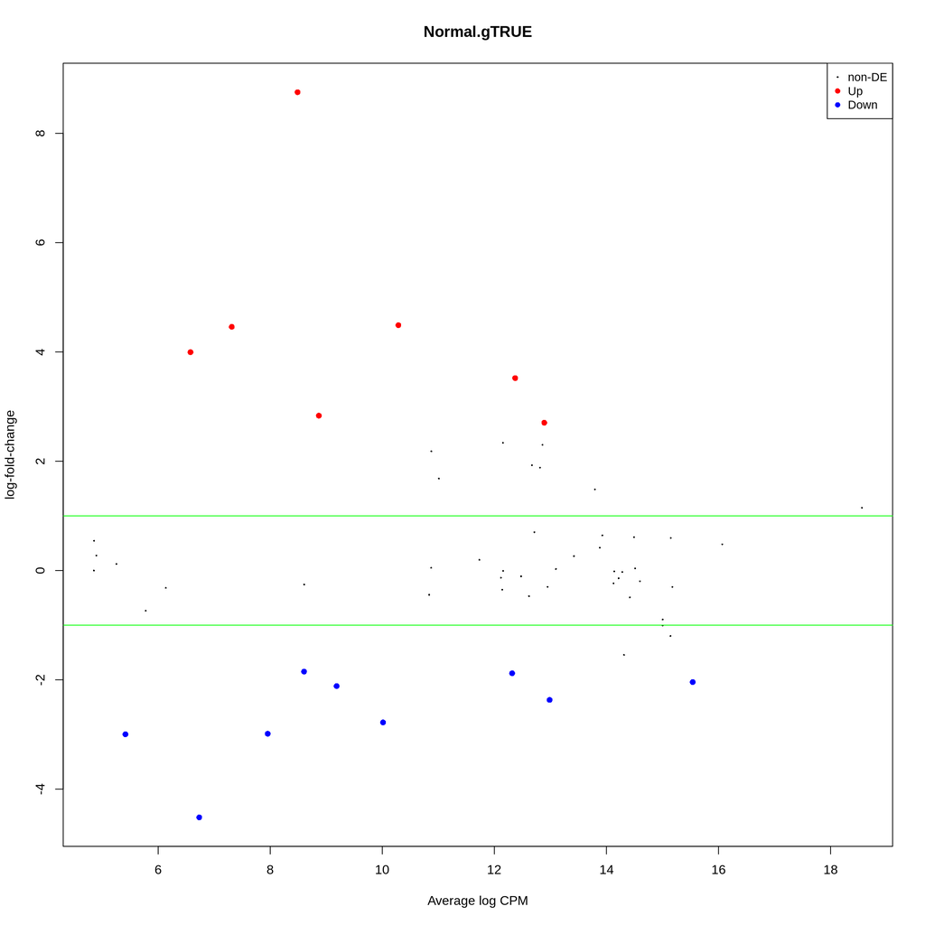

```r
plotMD(coad.lrt.g)
abline(h=c(-1, 1), col="green")
```

# Finding the nearest genes:

For the paired comparison:

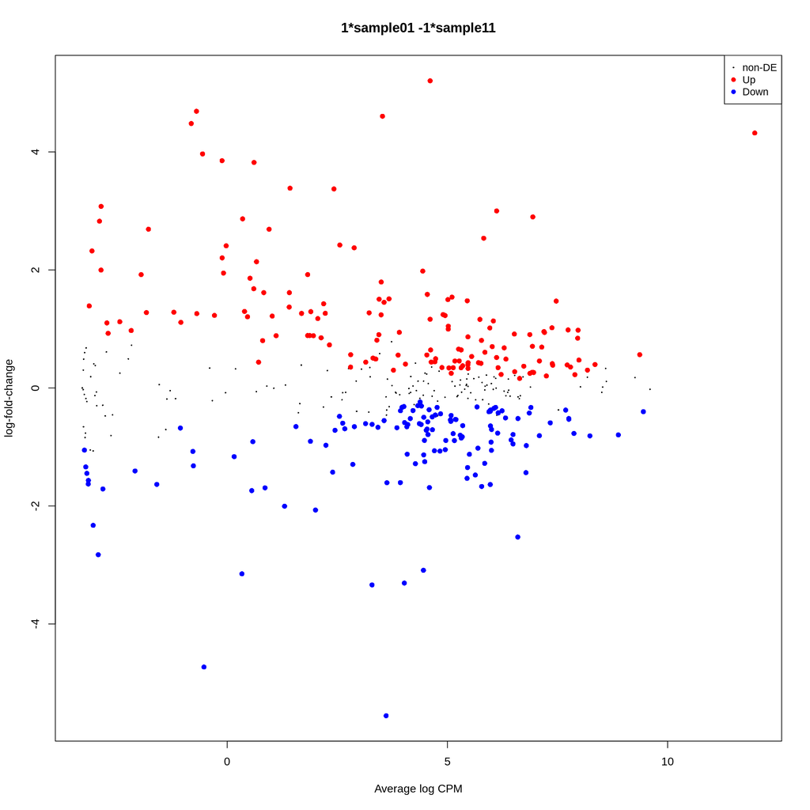

```r
prueba.coad<-(coad_fit.1[sapply(strsplit(rownames(coad_fit.1), '|', fixed = TRUE),
                                              function(x) return(x[1])) %in% overlaps.anno.fimo$gene_name,])


plotMD(prueba.coad)
```

```r
topTags(prueba.coad)
```

```
## Coefficient:  1*sample01 -1*sample11
##                    logFC     logCPM       LR       PValue          FDR
## CPNE7|27132    -5.555015  3.6083474 283.3449 1.401852e-63 6.027962e-61
## NPY|4852        4.688888 -0.6986930 188.3336 7.346601e-43 1.579519e-40
## CLDN23|137075   3.000082  6.1180387 148.2212 4.243959e-34 6.083008e-32
## LMBR1|64327    -1.019574  5.6929685 140.9288 1.667660e-32 1.792735e-30
## SPIB|6689       5.206016  4.6078304 134.6399 3.958195e-31 3.404048e-29
## TNNI3|7137     -4.729221 -0.5270213 131.8804 1.589135e-30 1.138880e-28
## JPH1|56704     -1.687800  4.5918857 116.6923 3.352462e-27 2.059369e-25
## XKR4|114786     4.480799 -0.8161766 114.7420 8.963181e-27 4.817710e-25
## SLC25A23|79085  1.471999  7.4705195 105.4005 9.978469e-25 4.767491e-23
## SOHLH2|54937    3.965924 -0.5591846 104.8413 1.323184e-24 5.689692e-23
```

```r
topTags(coad.lrt.g)
```

```
## Coefficient:  Normal.gTRUE
##                  logFC    logCPM       LR       PValue          FDR
## FOXG1|2290   -4.517139  6.733188 41.35634 1.268592e-10 7.611553e-09
## NRG1|3084     8.752508  8.487921 23.93707 9.953674e-07 2.986102e-05
## CYP27B1|1594 -2.779407 10.013877 22.57901 2.016760e-06 4.033519e-05
## TBX15|6913   -2.986757  7.954163 19.56999 9.698047e-06 1.454707e-04
## TFAP4|7023   -2.367614 12.985410 15.70920 7.386401e-05 8.863682e-04
## GC|2638      -2.996312  5.415557 14.96419 1.095709e-04 1.095709e-03
## IL6|3569      4.489710 10.286942 13.67125 2.177626e-04 1.866537e-03
## AR|367        4.459294  7.313261 11.79081 5.952378e-04 4.464283e-03
## NR3C1|2908    3.521729 12.372001 10.94313 9.395113e-04 5.720046e-03
## SLC7A1|6541  -2.041712 15.539737 10.91606 9.533410e-04 5.720046e-03
```

```r
overlaps.anno.fimo$id
```

[output not shown]

[output cut: 99 more lines]

```r
prueba.coad$table
```

[output not shown]

[output cut: 197 more lines]

[output not shown]